# Statistical report for ACASA-TAVI

AntiCoagulation versus AcetylSalicylic Acid after Transcatheter Aortic Valve Implantation

C. Cunen

01 juli 2026

# 1 Introduction

The ACASA-TAVI study is a two-arm, randomised, controlled, parallel-group, multicentre, single-country, open-label blinded-endpoint, Phase III trial. Patients are randomised to either ASA (usual care) or DOAC (active treatment) in a 1:1 ratio. The goal of the study is to evaluate the efficacy and safety of DOAC versus ASA after TAVI. Treatment duration is 12 months and the primary endpoints are evaluated at 12 months. See Protocol (current version is dated November 10th 2022).

This report summarises the results from the analysis of primary and secondary endpoints, as well as baseline and safety data.

The present results are built on *sham randomisation* generated from the most recent export from Viedoc. No true treatment assignments have been unlocked. All findings in this document should therefore be interpreted as preliminary and descriptive only. Final efficacy comparisons will not be conducted until the database is locked and genuine randomisation codes are used.

# 2 Patient enrolment and disposition

There are 360 randomised participants: 27 from Haukeland, 333 from OUS. The FAS includes all participants.

## 2.1 Patient disposition (reasons for non-completion)

Table 2.2: Overview of study completion and reasons for non-completion

|  | DOAC | ASA | Total |
| --- | --- | --- | --- |
| Number of randomised participants | 180 | 180 | 360 |
| Study completed |  |  |  |
| No | 14 | 10 | 24 |
| Yes | 166 | 170 | 336 |
| Reason for discontinuation |  |  |  |
| Voluntary discontinuation by patient | 4 | 5 | 9 |
| Incorrect randomisation | 1 | 0 | 1 |
| Non-compliance | 1 | 0 | 1 |
| Death | 7 | 5 | 12 |
| Other | 1 | 0 | 1 |

## 2.2 Protocol deviations

Number of major and minor protocol deviations, summarized by treatment group with details of type of deviation provided.

Table 2.4: Number of minor protocol deviations

| Treatment | Category of PD | n |
| --- | --- | --- |
| DOAC | Incorrect treatment and/or dose | 2 |
| DOAC | Prohibited concomitant medication | 3 |
| DOAC | Failure to collect important data | 6 |
| DOAC | Serious breach - Other | 1 |
| DOAC | Other | 10 |
| ASA | Prohibited concomitant medication | 3 |
| ASA | Failure to collect important data | 4 |
| ASA | Serious breach - SAE notification / safety procedure | 2 |
| ASA | Other | 8 |

There are currently no protocol deviations that are categorised as “major”.

# 3 Demographics and baseline characteristics

## 3.1 Table 1

Table 3.1: Baseline characteristics for all 360 participants. Continuous variables are summarised by mean (SD), or by median (IQR) as appopriate.

| Age (years) | 74.5 (3.7) |
| --- | --- |
| Sex, female | 37% |
| NYHA functional class III or IV | 29% |
| Body mass index (kg/m^2) | 28.1 (4.7) |
| Coronary artery disease | 24% |
| Hypertension | 71% |
| Diabetes mellitus | 28% |
| Previous stroke | 11% |
| Permanent pacemaker | 2% |
| Chronic obstructive pulmonary disease | 14% |
| EuroSCORE II (%) | 2.3 (2) |
| Troponin T (ng/L) | 16 (11 - 28) |
| NT-proBNP (ng/L) | 413 (197 - 812) |
| Glomerular filtration rate (mL/min/1 1.73 m^2) | 75 (18.4) |
| Pre-TAVI aortic valve parameters |  |
| Left ventricular ejection fraction (%) | 53.9 (8) |
| Aortic valve mean gradient (mmHg) | 49.6 (12.5) |
| Aortic valvular area (cm^2) | 0.8 (0.2) |
| Aortic annular area (mm^2) | 478.4 (93.6) |
| Aortic annular perimeter (mm) | 78.8 (7.7) |
| Bicuspid aortic valve | 14% |
| Valce-in-valve | 2% |
| Procedural characteristics |  |
| Balloon-expanded valve | 71% |
| Self-expandable valve | 29% |
| Pre-dilatation | 37% |
| Post-dilatation | 9% |

## 3.2 Demographics and medical history

Table 3.2: Demographics and medical history.

| Characteristic | DOAC(n=180) | ASA(n=180) | Overall (n=360) |
| --- | --- | --- | --- |
| Age (years) | 74.4 (3.7) | 74.5 (3.7) | 74.5 (3.7) |
| Sex, n (%) |  |  |  |
| Male | 115 (63.9%) | 111 (61.7%) | 226 (62.8%) |
| Female | 65 (36.1%) | 69 (38.3%) | 134 (37.2%) |
| Hypertension, n (%) |  |  |  |
| Yes | 124 (70.9%) | 126 (72%) | 250 (71.4%) |
| Missing | 5 (2.8%) | 5 (2.8%) | 10 (2.8%) |
| Coronary artery disease, n (%) |  |  |  |
| Yes | 36 (20.6%) | 47 (26.9%) | 83 (23.7%) |
| Missing | 5 (2.8%) | 5 (2.8%) | 10 (2.8%) |
| Diabetes mellitus, n (%) |  |  |  |
| Yes | 54 (30.9%) | 45 (25.7%) | 99 (28.3%) |
| Missing | 5 (2.8%) | 5 (2.8%) | 10 (2.8%) |
| Chronic obstructive pulmonary disease, n (%) |  |  |  |
| Yes | 26 (14.9%) | 22 (12.6%) | 48 (13.7%) |
| Missing | 5 (2.8%) | 5 (2.8%) | 10 (2.8%) |
| Previous stroke, n (%) |  |  |  |
| Yes | 19 (10.9%) | 21 (12%) | 40 (11.4%) |
| Missing | 5 (2.8%) | 5 (2.8%) | 10 (2.8%) |
| Permanent pacemaker |  |  |  |
| Yes | 5 (2.9%) | 3 (1.7%) | 8 (2.3%) |
| Missing | 5 (2.8%) | 5 (2.8%) | 10 (2.8%) |
| Smoking status, n (%) |  |  |  |
| Never smoked | 59 (32.8%) | 66 (36.7%) | 125 (34.7%) |
| Has stopped | 94 (52.2%) | 91 (50.6%) | 185 (51.4%) |
| Sometimes | 1 (0.6%) | 1 (0.6%) | 2 (0.6%) |
| Daily | 26 (14.4%) | 22 (12.2%) | 48 (13.3%) |

## 3.3 Vital signs and physical characteristics at baseline

Table 3.3: Vital signs and physical characteristics at baseline.

| Characteristic | DOAC(n=180) | ASA(n=180) | Overall (n=360) |
| --- | --- | --- | --- |
| Weight (kg) | 84.3 (16.2) | 84.9 (15.9) | 84.6 (16) |
| Height (cm) | 173.8 (9.3) | 173 (9) | 173.4 (9.1) |
| Body mass index (kg/m2) | 27.9 (4.9) | 28.3 (4.5) | 28.1 (4.7) |
| Systolic blood pressure (mmHg) | 137 (19.1) | 143.6 (22) | 140.3 (20.8) |
| Diastolic blood pressure (mmHg) | 71.9 (9.8) | 71.9 (10.4) | 71.9 (10.1) |
| Body temperature (C) | 36.7 (0.4) | 36.7 (0.4) | 36.7 (0.4) |
| Pulse rate (beats/min) | 74.7 (14.6) | 73 (11.6) | 73.8 (13.2) |
| Respiratory rate (breaths/min) | 16.9 (2.9) | 16.8 (2.2) | 16.8 (2.5) |
| Mini-Cog |  |  |  |
| Signs of cognitive impairment (0-2) | 15 (9.3%) | 11 (6.9%) | 26 (8.1%) |
| No cognitive impairment (3-5) | 147 (90.7%) | 148 (93.1%) | 295 (91.9%) |
| Missing | 18 (10%) | 21 (11.7%) | 39 (10.8%) |
| Five times sit-to-stand |  |  |  |
| < 15 sec | 115 (83.3%) | 109 (79.6%) | 224 (81.5%) |
| >= 15 sec | 23 (16.7%) | 28 (20.4%) | 51 (18.5%) |
| Missing | 42 (23.3%) | 43 (23.9%) | 85 (23.6%) |
| Frailty, n (%) |  |  |  |
| Robust | 75 (41.7%) | 90 (50%) | 165 (45.8%) |
| Pre-frail | 59 (32.8%) | 43 (23.9%) | 102 (28.3%) |
| Frail | 0 (0%) | 0 (0%) | 0 (0%) |
| Missing | 46 (25.6%) | 47 (26.1%) | 93 (25.8%) |

## 3.4 Clinical chemistry and hematology at baseline

Table 3.4: Some results related to clinical chemistry and hematology at baseline.

| Characteristic | DOAC(n=180) | ASA(n=180) | Overall (n=360) |
| --- | --- | --- | --- |
| Hemoglobin | 13.4 (1.6) | 13.7 (1.6) | 13.6 (1.6) |
| Platelets | 220.1 (61.7) | 232.9 (67) | 226.5 (64.7) |
| Leukocytes | 7.2 (6.1 - 8.6) | 7.4 (6.5 - 8.7) | 7.3 (6.3 - 8.7) |
| International Normalized Ratio (INR) | 1.1 (0.1) | 1 (0.1) | 1.1 (0.1) |
| Sodium | 139.5 (2.7) | 139.6 (2.8) | 139.6 (2.7) |
| Potassium | 4.1 (0.4) | 4 (0.4) | 4.1 (0.4) |
| ALT | 25.3 (13.3) | 27.6 (13.9) | 26.4 (13.6) |
| Cardiac troponin T | 17 (11.8 - 27.8) | 15 (11 - 28) | 16 (11 - 28) |
| NT-proBNP | 431 (216 - 815) | 372 (177 - 779) | 413 (197 - 812) |
| GFR | 73.6 (19.6) | 76.3 (17.1) | 75 (18.4) |
| Glucose | 6.8 (2) | 6.8 (2.2) | 6.8 (2.1) |
| Glycated haemoglobin (HbA1c) | 42.2 (9.3) | 42 (9.9) | 42.1 (9.6) |
| Triglycerides | 1.6 (0.9) | 1.5 (0.7) | 1.5 (0.8) |
| Missing | 6 (3.3%) | 4 (2.2%) | 10 (2.8%) |
| Total cholesterol | 4.2 (1.1) | 4.3 (1.1) | 4.2 (1.1) |
| HDL cholesterol | 1.4 (0.4) | 1.5 (0.5) | 1.4 (0.5) |
| LDL cholesterol | 2.2 (0.9) | 2.3 (0.9) | 2.3 (0.9) |
| Creatinine | 92.2 (46.8) | 84.8 (29.4) | 88.5 (39.2) |
| Albumin | 42.7 (3.8) | 43 (2.8) | 42.9 (3.3) |
| Missing | 6 (3.3%) | 4 (2.2%) | 10 (2.8%) |
| Bilirubin | 8.9 (4.5) | 9.9 (5.6) | 9.4 (5.1) |
| Missing | 6 (3.3%) | 4 (2.2%) | 10 (2.8%) |
| CRP | 1.6 (0.8 - 4) | 1.4 (0.7 - 3.3) | 1.5 (0.8 - 3.8) |

## 3.5 Echocardiography pre-TAVI and at baseline

Table 3.5: Some echocardiography parameters pre-TAVI.

| Characteristic | DOAC(n=180) | ASA(n=180) | Overall (n=360) |
| --- | --- | --- | --- |
| Aortic valve mean gradient (mmHg) | 49.4 (13) | 49.8 (12.1) | 49.6 (12.5) |
| LVOT (mm) | 22.7 (1.8) | 22.3 (1.9) | 22.5 (1.9) |
| Presence of low-flow low-gradient | 9 (5%) | 10 (5.6%) | 19 (5.3%) |
| Left ventricular ejection fraction (%) | 53.1 (7.9) | 54.7 (8) | 53.9 (8) |
| Left ventricular global longitudinal strain (%) | -15.2 (3.4) | -16.4 (8.8) | -15.8 (6.7) |
| Stroke volume (mL) | 83.8 (19.7) | 87 (23.1) | 85.4 (21.5) |
| Stroke volume index (mL per m^2) | 42.1 (10) | 43.5 (11.3) | 42.8 (10.7) |
| Aortic valvular area (cm^2) | 0.8 (0.2) | 0.8 (0.2) | 0.8 (0.2) |
| Aortic valve regurgitation | 116 (64.8%) | 113 (62.8%) | 229 (63.8%) |
| Missing echocardiography | 0 (0%) | 0 (0%) | 0 (0%) |

Table 3.6: Some echocardiography parameters at baseline (post-TAVI).

| Characteristic | DOAC(n=180) | ASA(n=180) | Overall (n=360) |
| --- | --- | --- | --- |
| Aortic valve mean gradient (mmHg) | 12.8 (4.7) | 13 (4.5) | 12.9 (4.6) |
| LVOT (mm) | 21.2 (2) | 21 (2) | 21.1 (2) |
| Presence of low-flow low-gradient | 44 (24.9%) | 30 (16.9%) | 74 (20.8%) |
| Left ventricular ejection fraction (%) | 57.5 (9) | 56.8 (9.7) | 57.1 (9.4) |
| Left ventricular global longitudinal strain (%) | -15.6 (3.4) | -15.6 (3.4) | -15.6 (3.4) |
| Stroke volume (mL) | 79.5 (14.7) | 82.7 (15.9) | 81.1 (15.4) |
| Stroke volume index (mL per m^2) | 39.7 (6.7) | 41.2 (7.2) | 40.4 (7) |
| Doppler velocity index | 0.5 (0.1) | 0.5 (0.1) | 0.5 (0.1) |
| Aortic valvular area (cm^2) | 1.9 (0.4) | 1.9 (0.4) | 1.9 (0.4) |
| Aortic valve regurgitation | 63 (35.2%) | 62 (34.4%) | 125 (34.8%) |
| Missing echocardiography | 60 (33.3%) | 56 (31.1%) | 116 (32.2%) |

# 4 Primary analyses of primary endpoints

## 4.1 Co-primary efficacy endpoint (HALT)

### 4.1.1 Descriptive statistics

Table 4.1: Descriptive statistics for HALT (primary efficacy endpoint). Counts and proportions.

|  | DOAC | ASA | Overall |
| --- | --- | --- | --- |
| Missing HALT | 15 | 10 | 25 |
| No thickening | 127 | 133 | 260 |
| HALT | 38 (23%) | 37 (21.8%) | 75 (22.4%) |
| HALT & Death | 45 (26.2%) | 42 (24%) | 87 (25.1%) |
| <=25% of leaflet | 20 | 17 | 37 |
| >25-50 % of leaflet | 13 | 9 | 22 |
| >50-75 % of lealet | 2 | 5 | 7 |
| >75 % of leaflet | 3 | 6 | 9 |
| Death | 7 | 5 | 12 |

### 4.1.2 Unadjusted analysis with multiple imputation

The analysis model only uses the treatment variable and no other covariates.

Multiple imputation with imputation model containing BMI, sodium, potassium, ALT, triglycerides, albumin, and bilirubin.

Table 4.2: Estimated average unadjusted risk ratio, along with corresponding p-value and confidence interval.

| contrast | estimate | p.value | 95CI_low | 95CI_high |
| --- | --- | --- | --- | --- |
| DOAC / ASA | 1.079 | 0.684 | 0.748 | 1.556 |

We see from the table above that the null hypothesis of equality is not rejected.

Table 4.3: Estimated average unadjusted risk difference, along with corresponding confidence interval.

| contrast | estimate | 95CI_low | 95CI_high |
| --- | --- | --- | --- |
| DOAC - ASA | 0.019 | -0.073 | 0.112 |

## 4.2 Co-primary safety endpoint

### 4.2.1 Descriptive statistics

Table 4.4: Descriptive statistics for primary safety endpoint. Counts and proportions. The counts are the number of participants experiencing an event of a particular type as their *first* safety event. Some participants may experience more than one safety event.

|  | DOAC | ASA | Overall |
| --- | --- | --- | --- |
| Missing | 4 | 2 | 6 |
| No safety events | 159 | 163 | 322 |
| Safety events | 17 (9.7%) | 15 (8.4%) | 32 (9%) |
| bleeding | 5 | 4 | 9 |
| death | 6 | 5 | 11 |
| mi | 2 | 2 | 4 |
| stroke | 4 | 4 | 8 |

**Occurrence and timing of intercurrent events**

Out of 360 participants, 55 participants experience some form of treatment deviation, mostly switching between the two study drugs. All participants have the possibility to switch between study drugs. A few participants switch multiple times.

Table 4.5: Number of participants with treatment deviations.

|  | No change in study drug | Switching or stopping | Early discontinuation |
| --- | --- | --- | --- |
| DOAC | 152 | 24 | 4 |
| ASA | 153 | 23 | 4 |
| Overall | 305 | 47 | 8 |

Out of the 32 safety events, 10 happen in participants that also switch between the treatments at some point. Among these 10 participants: 6 experience the safety event before switching, while 4 experience the safety event after their first switch.

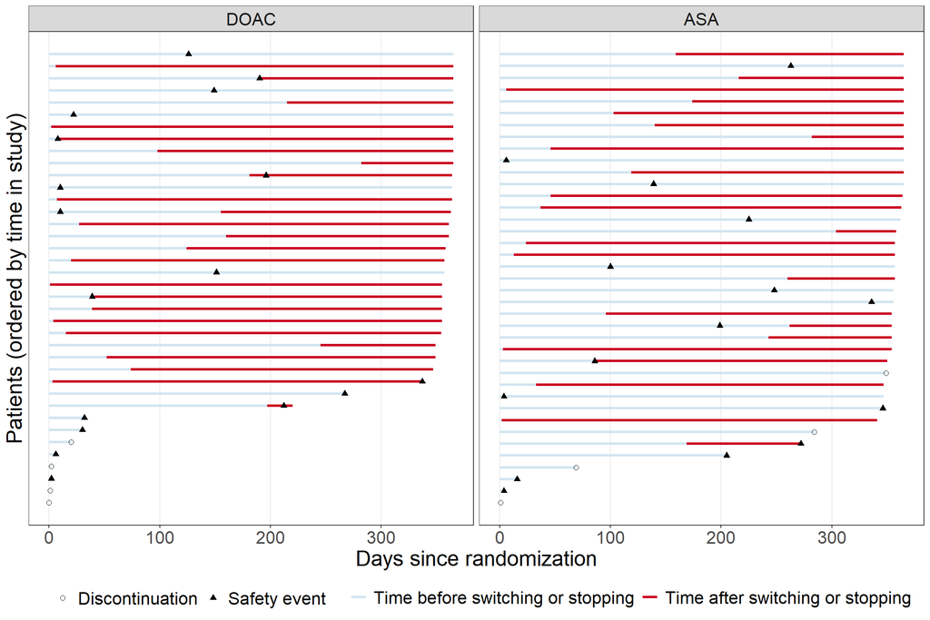

Figure 4.1: Timing of safety events and/or treatment deviations. Some participants switch between drugs multiple times and in those cases the figure gives the timing of the first switch.

In this figure there are 77 participants, including 32 participants experiencing the safety event, and 55 participants with treatment deviations (10 participants are part of both groups).

### 4.2.2 Adjusted analysis with multiple imputation, treatment policy strategy

> Should I show diagnostics of the imputation?

Covariates in the analysis model: treatment, age, sex, cad, prev_stroke, diabetes, hypertension, GFR

Multiple imputation with imputation model containing the same covariates.

Table 4.6: Estimated average adjusted risk difference, along with corresponding confidence interval.

| contrast | estimate | 95CI_low | 95CI_high |
| --- | --- | --- | --- |
| DOAC - ASA | 0.012 | -0.048 | 0.072 |

We see from the table above that the null hypothesis of inferiority is rejected.

Table 4.7: Estimated average adjusted risk ratio, along with corresponding confidence interval.

| contrast | estimate | 95CI_low | 95CI_high |
| --- | --- | --- | --- |
| DOAC / ASA | 1.141 | 0.588 | 2.214 |

## 4.3 Overall conclusions

Study is inconclusive.

# 5 Sensitivity analyses of primary endpoints

## 5.1 HALT

Table 5.1: Co-primary efficacy: results of primary analysis and 3 sensitivity analyses. Estimated average risk ratios, along with corresponding confidence intervals. MI stands for Mulitple Imputation.

|  | estimate | 95CI_low | 95CI_high |
| --- | --- | --- | --- |
| primary analysis | 1.079 | 0.748 | 1.556 |
| 1: adjusted, with MI | 0.956 | 0.673 | 1.358 |
| 2: unadjusted, complete-case | 1.090 | 0.757 | 1.569 |
| 3: unadjusted, worst-case | 1.128 | 0.807 | 1.575 |

Table 5.2: Co-primary efficacy: results of primary analysis and 3 sensitivity analyses. Estimated average risk differences, along with corresponding confidence intervals. MI stands for Mulitple Imputation.

|  | estimate | 95CI_low | 95CI_high |
| --- | --- | --- | --- |
| primary analysis | 0.019 | -0.073 | 0.112 |
| 1: adjusted, with MI | -0.011 | -0.100 | 0.077 |
| 2: unadjusted, complete-case | 0.022 | -0.070 | 0.113 |
| 3: unadjusted, worst-case | 0.033 | -0.059 | 0.126 |

## 5.2 Safety composite

Table 5.3: Co-primary safety: results of primary analysis and 3 sensitivity analyses. Estimated average risk differences, along with corresponding confidence intervals. MI stands for Mulitple Imputation.

|  | estimate | 95CI_low | 95CI_high |
| --- | --- | --- | --- |
| primary analysis | 0.012 | -0.048 | 0.072 |
| 1: unadjusted, with MI | 0.012 | -0.048 | 0.072 |
| 2: adjusted, complete-case | 0.012 | -0.048 | 0.072 |
| 3: adjusted, worst-case | 0.019 | -0.044 | 0.083 |

Table 5.4: Co-primary safety: results of primary analysis and 3 sensitivity analyses. Estimated average risk ratios, along with corresponding confidence intervals. MI stands for Mulitple Imputation.

|  | estimate | 95CI_low | 95CI_high |
| --- | --- | --- | --- |
| primary analysis | 1.141 | 0.588 | 2.214 |
| 1: unadjusted, with MI | 1.141 | 0.587 | 2.217 |
| 2: adjusted, complete-case | 1.144 | 0.590 | 2.215 |
| 3: adjusted, worst-case | 1.202 | 0.658 | 2.197 |

For the fourth sensitivity analysis we re-do the non-inferiority hypothesis test, but using the risk ratio and a non-inferiority margin of 1.35. We see from the table above that this null hypothesis of inferiority is not rejected.

# 6 Supplementary analyses of primary endpoints

## 6.1 HALT: hypothetical strategy for death

The analysis model only uses the treatment variable and no other covariates.

Multiple imputation with imputation model containing BMI, sodium, potassium, ALT, triglycerides, albumin, and bilirubin.

Table 6.1: Estimated average unadjusted risk ratio, along with corresponding p-value and confidence interval.

| contrast | estimate | p.value | 95CI_low | 95CI_high |
| --- | --- | --- | --- | --- |
| DOAC / ASA | 1.061 | 0.770 | 0.712 | 1.582 |

Table 6.2: Estimated average unadjusted risk difference, along with corresponding confidence interval.

| contrast | estimate | 95CI_low | 95CI_high |
| --- | --- | --- | --- |
| DOAC - ASA | 0.014 | -0.077 | 0.105 |

## 6.3 Safety compositet: composite strategy for treatment deviations

With this strategy we still have 360 observations, but now we have 77 safety events.

Table 6.3: Estimated average adjusted risk difference, along with corresponding confidence interval.

| contrast | estimate | 95CI_low | 95CI_high |
| --- | --- | --- | --- |
| DOAC - ASA | -0.017 | -0.101 | 0.067 |

Table 6.4: Estimated average adjusted risk ratio, along with corresponding p-value and confidence interval.

| contrast | estimate | p.value | 95CI_low | 95CI_high |
| --- | --- | --- | --- | --- |
| DOAC / ASA | 0.923 | 0.689 | 0.623 | 1.367 |

## 6.4 Safety composite: primary strata strategy for treatment deviations

With this strategy we now have 305 observations and 22 safety events.

Table 6.5: Estimated average adjusted risk difference, along with corresponding confidence interval.

| contrast | estimate | 95CI_low | 95CI_high |
| --- | --- | --- | --- |
| DOAC - ASA | -0.015 | -0.073 | 0.044 |

Table 6.6: Estimated average adjusted risk ratio, along with corresponding p-value and confidence interval.

| contrast | estimate | p.value | 95CI_low | 95CI_high |
| --- | --- | --- | --- | --- |
| DOAC / ASA | 0.817 | 0.625 | 0.364 | 1.834 |

# 7 Key secondary endpoints

## 7.1 Clinical efficacy

Table 7.1: Descriptive statistics for clinical efficacy composite by treatment arms and overall. Counts and proportions.

|  | DOAC | ASA | Overall |
| --- | --- | --- | --- |
| Missing | 6 | 7 | 13 |
| composite=0 | 45 | 44 | 89 |
| death | 7 | 5 | 12 |
| hospitalisation | 34 | 33 | 67 |
| KCCQ < 45 | 8 | 8 | 16 |
| decline in KCCQ > 10 | 5 | 9 | 14 |
| composite=1 | 129 | 129 | 258 |
| composite=1, % | 74.1% | 74.6% | 74.4% |

Table 7.2: Estimated average risk difference, along with corresponding confidence interval.

| contrast | estimate | 95CI_low | 95CI_high |
| --- | --- | --- | --- |
| DOAC - ASA | -0.008 | -0.100 | 0.083 |

Table 7.3: Estimated average risk ratio, along with corresponding confidence interval.

| contrast | estimate | 95CI_low | 95CI_high |
| --- | --- | --- | --- |
| DOAC / ASA | 0.989 | 0.874 | 1.118 |

## 7.2 Thromboembolic events

Table 7.4: Descriptive statistics for thromboembolic events by treatment arms and overall. Counts and proportions.

|  | DOAC | ASA | Overall |
| --- | --- | --- | --- |
| Missing | 8 | 4 | 12 |
| No thromboembolic event | 166 | 170 | 336 |
| With thromboembolic event | 6 | 6 | 12 |
| events, % | 3.5% | 3.4% | 3.4% |

Table 7.5: Estimated risk difference, along with corresponding confidence interval.

| contrast | estimate | 95CI_low | 95CI_high |
| --- | --- | --- | --- |
| DOAC - ASA | 0.000 | -0.042 | 0.042 |

## 7.3 Bleeding events

Table 7.6: Descriptive statistics for VARC-3 bleeding events by treatment arms and overall. Counts and proportions.

|  | DOAC | ASA | Overall |
| --- | --- | --- | --- |
| Missing | 5 | 3 | 8 |
| No bleeding events | 168 | 173 | 341 |
| VARC-3 bleeding events | 7 | 4 | 11 |
| Type 1 | 5 | 2 | 7 |
| Type 2 | 0 | 0 | 0 |
| Type 3 | 1 | 2 | 3 |
| Type 4 | 1 | 0 | 1 |
| VARC-3 bleeding events, % | 4% | 2.3% | 3.1% |

Table 7.7: Estimated risk difference, along with corresponding confidence interval.

| contrast | estimate | 95CI_low | 95CI_high |
| --- | --- | --- | --- |
| DOAC - ASA | 0.017 | -0.022 | 0.058 |

## 7.4 All-cause mortality

Table 7.8: Descriptive statistics for deaths by treatment arms and overall. Counts and proportions.

|  | DOAC | ASA | Overall |
| --- | --- | --- | --- |
| Missing | 0 | 0 | 0 |
| Alive at end-of-study | 173 | 175 | 348 |
| Deaths | 7 | 5 | 12 |
| Deaths from cardiovascular causes | 3 | 4 | 7 |
| Deaths, % | 3.9% | 2.8% | 3.3% |

Table 7.9: Estimated risk difference, along with corresponding confidence interval.

| contrast | estimate | 95CI_low | 95CI_high |
| --- | --- | --- | --- |
| DOAC - ASA | 0.011 | -0.030 | 0.053 |

## 7.5 Hemodynamic valve deterioration

Table 7.10: Descriptive statistics for HVD by treatment arms and overall. Counts and proportions.

|  | DOAC | ASA | Overall |
| --- | --- | --- | --- |
| Missing | 14 | 11 | 25 |
| No HVD (stage 0 or 1) | 142 | 147 | 289 |
| Stage 1 | 32 | 32 | 64 |
| HVD (stage 2 or 3) | 24 | 22 | 46 |
| Stage 3 | 0 | 0 | 0 |
| HVD (stage 2 or 3), % | 14.5% | 13% | 13.7% |
| HVD and death, % | 17.9% | 15.5% | 16.7% |

As, we see in the table above, no participant has HVD of stage 3.

Table 7.11: Estimated average risk difference, along with corresponding confidence interval.

| contrast | estimate | 95CI_low | 95CI_high |
| --- | --- | --- | --- |
| DOAC - ASA | 0.023 | -0.056 | 0.102 |

Table 7.12: Estimated average risk ratio, along with corresponding confidence interval.

| contrast | estimate | 95CI_low | 95CI_high |
| --- | --- | --- | --- |
| DOAC / ASA | 1.149 | 0.714 | 1.850 |

## 7.6 Safety composite with TIA

Table 7.13: Descriptive statistics for safety composite including TIA by treatment arms and overall. Counts and proportions.

|  | DOAC | ASA | Overall |
| --- | --- | --- | --- |
| Missing | 4 | 2 | 6 |
| No safety events | 155 | 159 | 314 |
| Safety events | 21 | 19 | 40 |
| bleeding | 7 | 4 | 11 |
| death | 7 | 5 | 12 |
| mi | 2 | 2 | 4 |
| stroke | 4 | 4 | 8 |
| tia | 6 | 4 | 10 |
| Safety events, % | 11.9% | 10.7% | 11.3% |

Table 7.14: Estimated average adjusted risk difference, along with corresponding confidence interval.

| contrast | estimate | 95CI_low | 95CI_high |
| --- | --- | --- | --- |
| DOAC - ASA | 0.011 | -0.055 | 0.077 |

Table 7.15: Estimated average adjusted risk ratio, along with corresponding confidence interval.

| contrast | estimate | 95CI_low | 95CI_high |
| --- | --- | --- | --- |
| DOAC / ASA | 1.104 | 0.615 | 1.983 |

# 8 Secondary safety endpoints

# 9 Sub-group analyses

## 9.1 HALT

These analyses use the treatment variable, the subgroup factor, their interaction, and no other covariates.

Multiple imputation with imputation model containing BMI, sodium, potassium, ALT, triglycerides, albumin, and bilirubin.

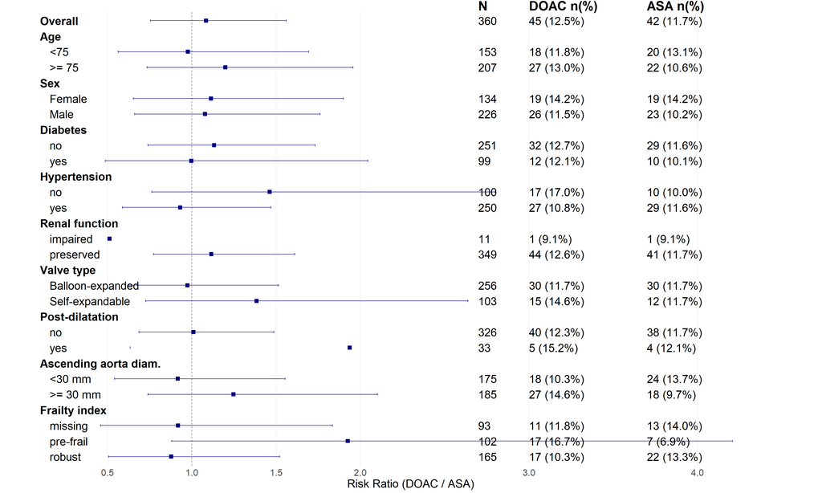

Figure 9.1: Forest plot of subgroup analyses for HALT.

Subgroups with few participants may get confidence intervals which are too wide to show in the figure above. In those case, check the tables below.

Table 9.1: Age subgroups and HALT. Estimated average unadjusted risk ratio, along with corresponding confidence interval.

| contrast | age | estimate | 95CI_low | 95CI_high |
| --- | --- | --- | --- | --- |
| DOAC / ASA | <75 | 0.977 | 0.563 | 1.694 |
| DOAC / ASA | >= 75 | 1.199 | 0.735 | 1.956 |

Table 9.2: Sex and HALT. Estimated average unadjusted risk ratio, along with corresponding confidence interval.

| contrast | sex | estimate | 95CI_low | 95CI_high |
| --- | --- | --- | --- | --- |
| DOAC / ASA | Male | 1.079 | 0.661 | 1.760 |
| DOAC / ASA | Female | 1.113 | 0.653 | 1.897 |

Table 9.3: Diabetes and HALT. Estimated average unadjusted risk ratio, along with corresponding confidence interval.

| contrast | diabetes | estimate | 95CI_low | 95CI_high |
| --- | --- | --- | --- | --- |
| DOAC / ASA | no | 1.132 | 0.740 | 1.732 |
| DOAC / ASA | yes | 0.997 | 0.486 | 2.044 |

Table 9.4: Hypertension and HALT. Estimated average unadjusted risk ratio, along with corresponding confidence interval.

| contrast | hypertension | estimate | 95CI_low | 95CI_high |
| --- | --- | --- | --- | --- |
| DOAC / ASA | no | 1.462 | 0.763 | 2.800 |
| DOAC / ASA | yes | 0.931 | 0.589 | 1.470 |

Table 9.5: Renal function and HALT. Estimated average unadjusted risk ratio, along with corresponding confidence interval.

| contrast | renal function | estimate | 95CI_low | 95CI_high |
| --- | --- | --- | --- | --- |
| DOAC / ASA | impaired | 0.512 | 0.048 | 5.473 |
| DOAC / ASA | preserved | 1.116 | 0.773 | 1.611 |

Table 9.6: Valve type and HALT. Estimated average unadjusted risk ratio, along with corresponding confidence interval.

| contrast | valve type | estimate | 95CI_low | 95CI_high |
| --- | --- | --- | --- | --- |
| DOAC / ASA | Balloon-expanded | 0.974 | 0.626 | 1.514 |
| DOAC / ASA | Self-expandable | 1.384 | 0.727 | 2.638 |

Table 9.7: Post-dilatation and HALT. Estimated average unadjusted risk ratio, along with corresponding confidence interval.

| contrast | post-dilatation | estimate | 95CI_low | 95CI_high |
| --- | --- | --- | --- | --- |
| DOAC / ASA | no | 1.010 | 0.686 | 1.486 |
| DOAC / ASA | yes | 1.937 | 0.634 | 5.914 |

Table 9.8: Ascending aorta diameter and HALT. Estimated average unadjusted risk ratio, along with corresponding confidence interval.

| contrast | ascending aorta diam. | estimate | 95CI_low | 95CI_high |
| --- | --- | --- | --- | --- |
| DOAC / ASA | <30 mm | 0.917 | 0.542 | 1.554 |
| DOAC / ASA | >= 30 mm | 1.247 | 0.740 | 2.101 |

Table 9.9: Frailty and HALT. Estimated average unadjusted risk ratio, along with corresponding confidence interval.

| contrast | frailty index | estimate | 95CI_low | 95CI_high |
| --- | --- | --- | --- | --- |
| DOAC / ASA | robust | 0.877 | 0.506 | 1.521 |
| DOAC / ASA | pre-frail | 1.925 | 0.880 | 4.209 |
| DOAC / ASA | missing | 0.918 | 0.460 | 1.834 |

## 9.2 Safety composite

These analyses use the treatment variable, the subgroup factor, their interaction, and covariates age, sex, cad, prev_stroke, diabetes, hypertension, GFR.

Multiple imputation with imputation model containing treatment, age, sex, cad, prev_stroke, diabetes, hypertension, GFR.

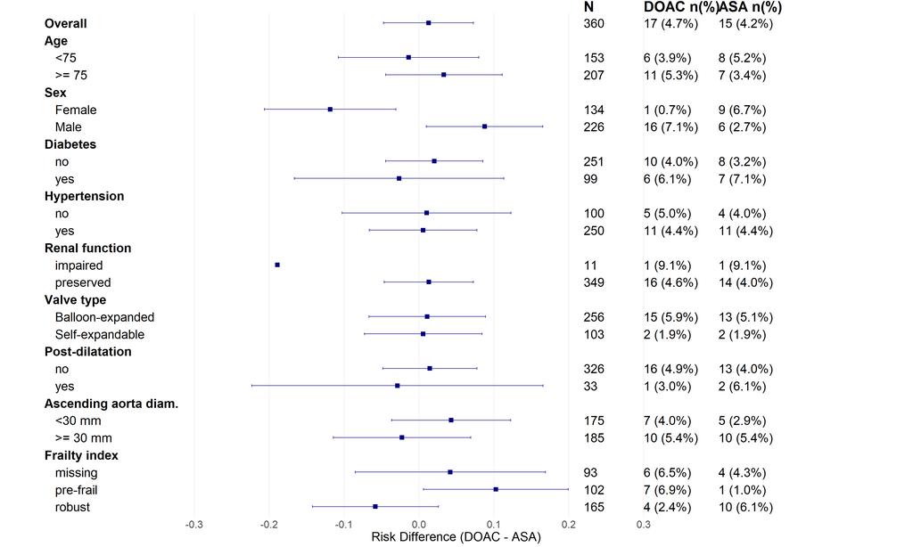

Figure 9.2: Forest plot of subgroup analyses for safety composite.

Subgroups with few participants may get confidence intervals which are too wide to show in the figure above. In those case, check the tables below.

Table 9.10: Age subgroups and safety risk. Estimated average adjusted risk difference, along with corresponding confidence interval.

| contrast | age | estimate | 95CI_low | 95CI_high |
| --- | --- | --- | --- | --- |
| DOAC - ASA | <75 | -0.014 | -0.108 | 0.080 |
| DOAC - ASA | >= 75 | 0.033 | -0.044 | 0.111 |

Table 9.11: Sex and safety risk. Estimated average adjusted risk difference, along with corresponding confidence interval.

| contrast | sex | estimate | 95CI_low | 95CI_high |
| --- | --- | --- | --- | --- |
| DOAC - ASA | Male | 0.088 | 0.010 | 0.165 |
| DOAC - ASA | Female | -0.119 | -0.206 | -0.031 |

Table 9.12: Diabetes and safety risk. Estimated average adjusted risk difference, along with correspondin confidence interval.

| contrast | diabetes | estimate | 95CI_low | 95CI_high |
| --- | --- | --- | --- | --- |
| DOAC - ASA | no | 0.020 | -0.045 | 0.085 |
| DOAC - ASA | yes | -0.027 | -0.166 | 0.113 |

Table 9.13: Hypertension and safety risk. Estimated average adjusted risk difference, along with corresponding confidence interval.

| contrast | hypertension | estimate | 95CI_low | 95CI_high |
| --- | --- | --- | --- | --- |
| DOAC - ASA | no | 0.010 | -0.102 | 0.123 |
| DOAC - ASA | yes | 0.006 | -0.066 | 0.078 |

Table 9.14: Renal function and safety risk. Estimated average adjusted risk difference, along with corresponding confidence interval.

| contrast | renal function | estimate | 95CI_low | 95CI_high |
| --- | --- | --- | --- | --- |
| DOAC - ASA | impaired | -0.189 | -0.796 | 0.417 |
| DOAC - ASA | preserved | 0.013 | -0.047 | 0.073 |

Table 9.15: Valve type and safety risk. Estimated average adjusted risk difference, along with corresponding confidence interval.

| contrast | valve type | estimate | 95CI_low | 95CI_high |
| --- | --- | --- | --- | --- |
| DOAC - ASA | Balloon-expanded | 0.011 | -0.067 | 0.089 |
| DOAC - ASA | Self-expandable | 0.006 | -0.073 | 0.084 |

Table 9.16: Post-dilatation and safety risk. Estimated average adjusted risk difference, along with corresponding confidence interval.

| contrast | post-dilatation | estimate | 95CI_low | 95CI_high |
| --- | --- | --- | --- | --- |
| DOAC - ASA | no | 0.014 | -0.048 | 0.077 |
| DOAC - ASA | yes | -0.029 | -0.223 | 0.166 |

Table 9.17: Ascending aorta diameter and safety risk. Estimated average adjusted risk difference, along with corresponding confidence interval.

| contrast | ascending aorta diam. | estimate | 95CI_low | 95CI_high |
| --- | --- | --- | --- | --- |
| DOAC - ASA | <30 mm | 0.043 | -0.036 | 0.122 |
| DOAC - ASA | >= 30 mm | -0.023 | -0.114 | 0.069 |

Table 9.18: Frailty and safety risk. Estimated average adjusted risk difference, along with corresponding confidence interval.

| contrast | frailty index | estimate | 95CI_low | 95CI_high |
| --- | --- | --- | --- | --- |
| DOAC - ASA | robust | -0.058 | -0.142 | 0.026 |
| DOAC - ASA | pre-frail | 0.103 | 0.006 | 0.199 |
| DOAC - ASA | missing | 0.042 | -0.085 | 0.169 |

# 10 Additional safety analysis

> Which numbers and tables do you want to see here? The two first tables are kind of redundant, but the question is whether one should require that the AE is possibly related to study medication or not.

## 10.1 Overview of adverse events, serious adverse events and suspected unexpected serious adverse reaction

Table 10.1: Summary of adverse events.

|  | DOAC (n=180) | ASA (n=180) | Overall (n=360) |
| --- | --- | --- | --- |
| Number of AEs | 260 | 255 | 515 |
| Number of patients with any AEs | 119 (66.1%) | 114 (63.3%) | 233 (64.7%) |
| Number of patients with one AE | 56 (31.1%) | 43 (23.9%) | 99 (27.5%) |
| Number of patients with two AE | 27 (15%) | 41 (22.8%) | 68 (18.9%) |
| Number of patients with three or more AEs | 36 (20%) | 30 (16.7%) | 66 (18.3%) |
| Number of SAEs | 124 | 113 | 237 |
| Number of patients with any SAEs | 72 (40%) | 67 (37.2%) | 139 (38.6%) |

There are no SUSARs in the dataset. No SAE which is unexpected and possibly, probably or definitely related to study medication.

## 10.2 Suspected adverse reactions: AEs and SAEs with a possible, probable or definite relation to study treatments

Table 10.2: Summary of adverse events with a possible, probable or definite relation to study treatments.

[output not shown]

There are no SUSARs in the dataset.

## 10.3 Adverse Events by System Organ Class and Preferred term

Table 10.3: Number of AEs and SAEs by system organ class and preferred term.

| System organ class | Preferred term | AE DOAC | AE ASA | SAE DOAC | SAE ASA |
| --- | --- | --- | --- | --- | --- |
| blood and lymphatic system disorders | anaemia | 1 | 3 | 0 | 2 |
|  | haemolytic anaemia | 0 | 0 | 0 | 1 |
|  | iron deficiency anaemia | 0 | 0 | 1 | 0 |
| cardiac disorders | acute coronary syndrome | 0 | 0 | 0 | 1 |
|  | acute myocardial infarction | 0 | 0 | 2 | 1 |
|  | angina pectoris | 1 | 0 | 0 | 0 |
|  | atrial fibrillation | 11 | 16 | 2 | 2 |
|  | atrial flutter | 3 | 0 | 0 | 0 |
|  | atrioventricular block | 1 | 1 | 2 | 2 |
|  | atrioventricular block complete | 1 | 0 | 4 | 2 |
|  | atrioventricular block first degree | 0 | 0 | 1 | 0 |
|  | atrioventricular block second degree | 0 | 0 | 2 | 1 |
|  | cardiac arrest | 0 | 0 | 1 | 3 |
|  | cardiac failure | 3 | 1 | 7 | 5 |
|  | myocardial infarction | 0 | 0 | 0 | 1 |
|  | nodal rhythm | 1 | 0 | 1 | 0 |
|  | pericardial effusion | 0 | 1 | 1 | 0 |
|  | pericarditis | 0 | 0 | 0 | 1 |
|  | ventricular arrhythmia | 0 | 0 | 1 | 0 |
|  | ventricular tachycardia | 1 | 0 | 2 | 0 |
| ear and labyrinth disorders | sudden hearing loss | 0 | 1 | 0 | 0 |
|  | vertigo positional | 1 | 0 | 1 | 0 |
| endocrine disorders | hypothyroidism | 0 | 1 | 0 | 0 |
| eye disorders | amaurosis fugax | 4 | 0 | 1 | 3 |
|  | blindness | 0 | 1 | 0 | 0 |
|  | conjunctival haemorrhage | 0 | 1 | 0 | 0 |
|  | diplopia | 1 | 1 | 0 | 0 |
|  | vision blurred | 1 | 1 | 0 | 0 |
|  | visual impairment | 2 | 3 | 0 | 0 |
|  | vitreous haemorrhage | 0 | 0 | 0 | 2 |

[output cut: 166 more lines]